# Phase 2.1, step 01: exploratory factor analysis

## What this notebook does

It reproduces the exploratory factor analysis (EFA) of the exploratory survey (65 items, 506 participants), run on 2026-03-18 with `Notebooks/01_Notebooks/01-EFAFactorLoadings.Rmd` of the OSF supplemental folder. For the whole sample (`Agg`) and for each of the five tools it computes:

1. missing data (percentage, Little’s MCAR test) and multivariate normality (Mardia);
2. the **polychoric** correlation matrix (`psych::polychoric`, default settings);
3. factorability: KMO, Bartlett’s test, determinant, Cronbach’s α (from the data and from the matrix);
4. the scree plot with **parallel analysis** (`fa.parallel`, `fa = "fa"`);
5. EFA with **principal axis** extraction (`fm = "pa"`) on the polychoric matrix: 1 factor without rotation, 2–6 factors with **promax** rotation; loadings sorted with `fa.sort`;
6. fit indices of each solution (RMSEA, TLI, BIC, RMSR, χ², df), as in `01-EFAModelFitIndex.Rmd`.

At the end it compares the loadings, the correlations and the KMO with the results of 2026-03-18.

Changes from the original notebook, none of which changes a result:

- input files are listed by name (the original took every `.csv` of `Data/` and dropped the 7th, which breaks when a file is added);
- items are named by their code (the original used code + wording as column names);
- a seed is set before the parallel analysis;
- the factor weights and the correlation plots in other orders (AOE, hclust) are not written.

## Data

```r
groups <- c(
  "Tableau"  = "by-tool/ratings-tableau_collapsed.csv",
  "Qlik"     = "by-tool/ratings-qlik_collapsed.csv",
  "Power BI" = "by-tool/ratings-power-bi_collapsed.csv",
  "Gephi"    = "by-tool/ratings-gephi_collapsed.csv",
  "JMP"      = "by-tool/ratings-jmp_collapsed.csv",
  "Agg"      = "ratings-stimulus_collapsed.csv"
)
data_dir <- here(params$data_dir)
read_group <- function(file) {
  d <- read.csv(file.path(data_dir, file), check.names = FALSE)
  d[, setdiff(names(d), c("seed", "stimulus"))]
}
datasets <- lapply(groups, read_group)
data.frame(group = names(datasets), file = unname(groups),
           participants = sapply(datasets, nrow), items = sapply(datasets, ncol),
           md5 = unname(tools::md5sum(file.path(data_dir, groups))))
```

```
##             group                                   file participants items
## Tableau   Tableau  by-tool/ratings-tableau_collapsed.csv          100    65
## Qlik         Qlik     by-tool/ratings-qlik_collapsed.csv          101    65
## Power BI Power BI by-tool/ratings-power-bi_collapsed.csv          102    65
## Gephi       Gephi    by-tool/ratings-gephi_collapsed.csv          104    65
## JMP           JMP      by-tool/ratings-jmp_collapsed.csv           99    65
## Agg           Agg         ratings-stimulus_collapsed.csv          506    65
##                                       md5
## Tableau  8b0425d07ca3525f6ea634a1ced03803
## Qlik     58a658762cc9a50c108d783941a67ef4
## Power BI c8c3782ca44069195765955c8f41ecd4
## Gephi    1966dca0617a6fa3cb07b84b3714e1b3
## JMP      f2adb204385279b42440c9c61622c6d1
## Agg      eb83954b17ac6ef2149f63f4f7c0c572
```

The aggregate file is collapsed over the whole sample; each per-tool file is collapsed within its tool (see `data/README.md`). This is how the files of 2026-03-18 were made.

## Analysis

```r
group_slug <- function(g) tolower(gsub(" ", "-", g))

analyse_group <- function(g, data) {
  n <- nrow(data)
  # missing data and normality
  na_pct <- 100 * sum(is.na(data)) / (nrow(data) * ncol(data))
  mcar_p <- tryCatch(naniar::mcar_test(data)$p.value, error = function(e) NA_real_)
  mardia_res <- psych::mardia(data, plot = FALSE)

  # polychoric correlations
  rho <- psych::polychoric(data)$rho
  write.csv(rho, file.path(out_dir, "correlations", paste0("polychoric-", group_slug(g), ".csv")))

  # factorability
  kmo <- psych::KMO(rho)$MSA
  bart <- psych::cortest.bartlett(rho, n = n)
  alpha_data   <- psych::alpha(data, warnings = FALSE)$total$raw_alpha
  alpha_matrix <- psych::alpha(rho, n.obs = n, warnings = FALSE)$total$raw_alpha

  # parallel analysis
  set.seed(params$seed)
  pdf(file.path(out_dir, "plots", paste0("scree-", group_slug(g), ".pdf")), width = 8, height = 4)
  pa <- psych::fa.parallel(rho, n.obs = n, fa = "fa", n.iter = params$pa_iterations,
                           main = paste("Scree plot with parallel analysis:", g), plot = TRUE)
  dev.off()

  # EFA, 1 to n_factors_max factors
  fits <- list()
  for (k in seq_len(params$n_factors_max)) {
    efa_fit <- psych::fa(rho, n.obs = n, nfactors = k, rotate = if (k == 1) "none" else "promax", fm = "pa")
    efa <- psych::fa.sort(efa_fit)   # fa.sort drops some fit statistics (CFI): fit is read from efa_fit
    loadings <- as.data.frame(unclass(efa$loadings))
    variance <- as.data.frame(efa$Vaccounted)[, names(loadings), drop = FALSE]
    separator <- as.data.frame(setNames(rep(list(NA_real_), ncol(loadings)), names(loadings)))
    out <- rbind(data.frame(terms = rownames(loadings), loadings, check.names = FALSE),
                 data.frame(terms = "--- VARIANCE EXPLAINED ---", separator, check.names = FALSE),
                 data.frame(terms = rownames(variance), variance, check.names = FALSE))
    rownames(out) <- NULL
    write.csv(out, file.path(out_dir, "loadings", sprintf("pa-%d-factors-%s.csv", k, group_slug(g))),
              row.names = FALSE, na = "")
    fits[[k]] <- data.frame(group = g, factors = k,
                            chi_sq = efa_fit$STATISTIC, df = efa_fit$dof,
                            rmsea = efa_fit$RMSEA[1], rmsea_lower = efa_fit$RMSEA[2], rmsea_upper = efa_fit$RMSEA[3],
                            cfi = efa_fit$CFI, tli = efa_fit$TLI, bic = efa_fit$BIC, rmsr = efa_fit$rms)
  }

  list(
    summary = data.frame(group = g, n = n, na_pct = na_pct, mcar_p = mcar_p,
                         kmo = kmo, bartlett_chisq = bart$chisq, bartlett_df = bart$df, bartlett_p = bart$p.value,
                         determinant = det(rho), alpha_data = alpha_data, alpha_matrix = alpha_matrix,
                         mardia_kurtosis = mardia_res$kurtosis, mardia_kurtosis_p = mardia_res$p.kurt,
                         mardia_skew = mardia_res$skew, mardia_skew_p = mardia_res$p.skew,
                         parallel_n_factors = pa$nfact),
    fit = do.call(rbind, fits),
    rho = rho
  )
}
```

```r
results <- lapply(names(datasets), function(g) analyse_group(g, datasets[[g]]))
```

```
## Parallel analysis suggests that the number of factors =  2  and the number of components =  NA
```

```
## Parallel analysis suggests that the number of factors =  2  and the number of components =  NA
```

```
## Parallel analysis suggests that the number of factors =  4  and the number of components =  NA
```

```
## Parallel analysis suggests that the number of factors =  2  and the number of components =  NA
```

```
## Parallel analysis suggests that the number of factors =  3  and the number of components =  NA
```

```
## Parallel analysis suggests that the number of factors =  5  and the number of components =  NA
```

```r
names(results) <- names(datasets)

summary_table <- do.call(rbind, lapply(results, `[[`, "summary"))
fit_table     <- do.call(rbind, lapply(results, `[[`, "fit"))
rownames(summary_table) <- NULL
rownames(fit_table) <- NULL
write.csv(summary_table, file.path(out_dir, "sampling-adequacy-summary.csv"), row.names = FALSE)
write.csv(fit_table, file.path(out_dir, "fit-indices.csv"), row.names = FALSE)
```

### Missing data, normality and factorability

```r
knitr::kable(summary_table, digits = 3)
```

| group | n | na_pct | mcar_p | kmo | bartlett_chisq | bartlett_df | bartlett_p | determinant | alpha_data | alpha_matrix | mardia_kurtosis | mardia_kurtosis_p | mardia_skew | mardia_skew_p | parallel_n_factors |
| --- | --- | --- | --- | --- | --- | --- | --- | --- | --- | --- | --- | --- | --- | --- | --- |
| Tableau | 100 | 0.538 | 0.000 | 0.812 | 30041.17 | 2080 | 0 | 0 | 0.976 | 0.983 | -5.778 | 0.000 | 47133.42 | 0.994 | 2 |
| Qlik | 101 | 0.899 | 0.000 | 0.725 | 26288.17 | 2080 | 0 | 0 | 0.971 | 0.977 | -5.073 | 0.000 | 47437.40 | 0.935 | 2 |
| Power BI | 102 | 0.784 | 0.031 | 0.592 | 23041.80 | 2080 | 0 | 0 | 0.953 | 0.967 | -7.876 | 0.000 | 45941.02 | 1.000 | 4 |
| Gephi | 104 | 1.583 | 0.000 | 0.816 | 29887.83 | 2080 | 0 | 0 | 0.976 | 0.985 | -3.803 | 0.000 | 48064.40 | 0.303 | 2 |
| JMP | 99 | 0.668 | 0.000 | 0.811 | 29456.75 | 2080 | 0 | 0 | 0.974 | 0.982 | -1.700 | 0.089 | 49245.67 | 0.000 | 3 |
| Agg | 506 | 0.900 | 1.000 | 0.964 | 24036.84 | 2080 | 0 | 0 | 0.972 | 0.980 | 100.861 | 0.000 | 83917.54 | 0.000 | 5 |

- **Little’s MCAR test**: p < .05 rejects “missing completely at random”.
- **Mardia**: p < .05 rejects multivariate normality, one reason for principal axis extraction.
- **KMO** ≥ 0.70 and a significant **Bartlett** test indicate that the matrix is suitable for factor analysis.
- **parallel_n_factors** is the number of factors suggested by parallel analysis (random; see the seed above).

### Item-level normality (whole sample)

Skewness and excess kurtosis of each item (`psych::skew` and `psych::kurtosi`, `type = 2`, the estimates reported by SPSS), before and after collapsing rare options, and the Shapiro-Wilk test. Thresholds of Fabrigar et al. (1999) for a severe violation: |skewness| > 2, kurtosis > 7.

```r
raw <- read.csv(here(params$raw_file), check.names = FALSE, fileEncoding = "UTF-8-BOM")
raw <- raw[, names(datasets[["Agg"]])]
agg <- datasets[["Agg"]]
item_normality <- data.frame(
  item = names(agg),
  skew_raw = psych::skew(raw, type = 2), kurtosis_raw = psych::kurtosi(raw, type = 2),
  skew_collapsed = psych::skew(agg, type = 2), kurtosis_collapsed = psych::kurtosi(agg, type = 2),
  shapiro_p_raw = sapply(raw, function(x) shapiro.test(x)$p.value),
  # ceiling and left tail, uncollapsed answers (share of non-missing answers)
  share_top_2_3 = sapply(raw, function(x) mean(x[!is.na(x)] >= 2)),
  share_negative = sapply(raw, function(x) mean(x[!is.na(x)] < 0)),
  row.names = NULL)
write.csv(item_normality, file.path(out_dir, "item-normality.csv"), row.names = FALSE)

count_table <- data.frame(
  data = c("uncollapsed", "collapsed (EFA input)"),
  skew_min = c(min(item_normality$skew_raw), min(item_normality$skew_collapsed)),
  skew_max = c(max(item_normality$skew_raw), max(item_normality$skew_collapsed)),
  kurtosis_min = c(min(item_normality$kurtosis_raw), min(item_normality$kurtosis_collapsed)),
  kurtosis_max = c(max(item_normality$kurtosis_raw), max(item_normality$kurtosis_collapsed)),
  items_abs_skew_gt_1 = c(sum(abs(item_normality$skew_raw) > 1), sum(abs(item_normality$skew_collapsed) > 1)),
  items_abs_skew_gt_2 = c(sum(abs(item_normality$skew_raw) > 2), sum(abs(item_normality$skew_collapsed) > 2)),
  items_kurtosis_gt_7 = c(sum(item_normality$kurtosis_raw > 7), sum(item_normality$kurtosis_collapsed > 7)))
knitr::kable(count_table, digits = 2)
```

| data | skew_min | skew_max | kurtosis_min | kurtosis_max | items_abs_skew_gt_1 | items_abs_skew_gt_2 | items_kurtosis_gt_7 |
| --- | --- | --- | --- | --- | --- | --- | --- |
| uncollapsed | -1.66 | -0.46 | -0.72 | 4.88 | 39 | 0 | 0 |
| collapsed (EFA input) | -1.23 | -0.37 | -0.75 | 2.09 | 10 | 0 | 0 |

```r
cat("Items rejecting normality (Shapiro-Wilk, uncollapsed, p < .05):",
    sum(item_normality$shapiro_p_raw < .05), "of", nrow(item_normality), "\n")
```

```
## Items rejecting normality (Shapiro-Wilk, uncollapsed, p < .05): 65 of 65
```

```r
cat(sprintf("Ceiling: %d of %d items have at least half of their answers in 2 or 3 (median item %.0f%%, range %.0f%%-%.0f%%); negative answers: median item %.1f%%, largest %.1f%%.\n",
            sum(item_normality$share_top_2_3 >= .5), nrow(item_normality),
            100 * median(item_normality$share_top_2_3), 100 * min(item_normality$share_top_2_3),
            100 * max(item_normality$share_top_2_3),
            100 * median(item_normality$share_negative), 100 * max(item_normality$share_negative)))
```

```
## Ceiling: 59 of 65 items have at least half of their answers in 2 or 3 (median item 72%, range 36%-88%); negative answers: median item 3.6%, largest 27.1%.
```

### Item histograms (uncollapsed answers)

One panel per item with the number of answers for each option, before rare options are merged. The dashed line marks 2.5% of the item’s non-missing answers, the merging threshold of `data/prepare_data.py`. The items are grouped by the factor of their largest loading in the three-factor solution of the whole sample, in the order of `loadings/pa-3-factors-agg.csv` (by factor, then by loading, as in the paper’s table of the three factors). Written to `output/plots/figure-histograms-<factor>.pdf`. This replaces the histograms of `01-EFA-Histograms.Rmd` (OSF folder), which used 10 bins on the 7-point scale and kept only the last group’s figure.

```r
# --- item histograms (uncollapsed answers), one figure per factor ----------------------------------------
# "I don't know / not applicable" answers are missing and not drawn.
hist_long <- do.call(rbind, lapply(names(raw), function(it) {
  x <- raw[[it]]; x <- x[!is.na(x)]
  data.frame(item = it, option = -3:3, n = as.vector(table(factor(x, levels = -3:3))),
             threshold = 0.025 * length(x))
}))
three_agg <- read.csv(file.path(out_dir, "loadings", "pa-3-factors-agg.csv"), check.names = FALSE)
three_agg <- three_agg[seq_len(which(three_agg$terms == "--- VARIANCE EXPLAINED ---") - 1), ]
three_L <- apply(three_agg[, c("PA1", "PA2", "PA3")], 2, as.numeric); rownames(three_L) <- three_agg$terms
factor_names <- c(PA1 = "task-cognition", PA2 = "system", PA3 = "visualization")
factor_of <- colnames(three_L)[apply(three_L, 1, which.max)]
names(factor_of) <- rownames(three_L)
items_by_factor <- lapply(names(factor_names), function(f) rownames(three_L)[factor_of == f])  # file order
names(items_by_factor) <- factor_names

draw_histograms <- function(its, ncol = 6) {
  d <- hist_long[hist_long$item %in% its, ]
  d$item <- factor(d$item, levels = its)
  ggplot2::ggplot(d, ggplot2::aes(x = option, y = n)) +
    ggplot2::geom_col(fill = "grey45", width = 0.8) +
    ggplot2::geom_hline(ggplot2::aes(yintercept = threshold), linetype = "dashed", linewidth = 0.3) +
    ggplot2::facet_wrap(~ item, ncol = ncol) +
    ggplot2::scale_x_continuous(breaks = -3:3) +
    ggplot2::labs(x = "Answer option (-3 = strongly disagree, +3 = strongly agree)", y = "Number of answers") +
    ggplot2::theme_minimal(base_size = 8) +
    ggplot2::theme(panel.grid.minor = ggplot2::element_blank(), panel.grid.major.x = ggplot2::element_blank(),
                   strip.text = ggplot2::element_text(face = "bold"))
}
for (f in names(items_by_factor)) {
  its <- items_by_factor[[f]]
  rows <- ceiling(length(its) / 6)
  ggplot2::ggsave(file.path(out_dir, "plots", sprintf("figure-histograms-%s.pdf", f)),
                  draw_histograms(its), width = 7.2, height = 1.25 * rows + 0.6)
}
sapply(items_by_factor, length)
```

```
## task-cognition         system  visualization
##             25             18             22
```

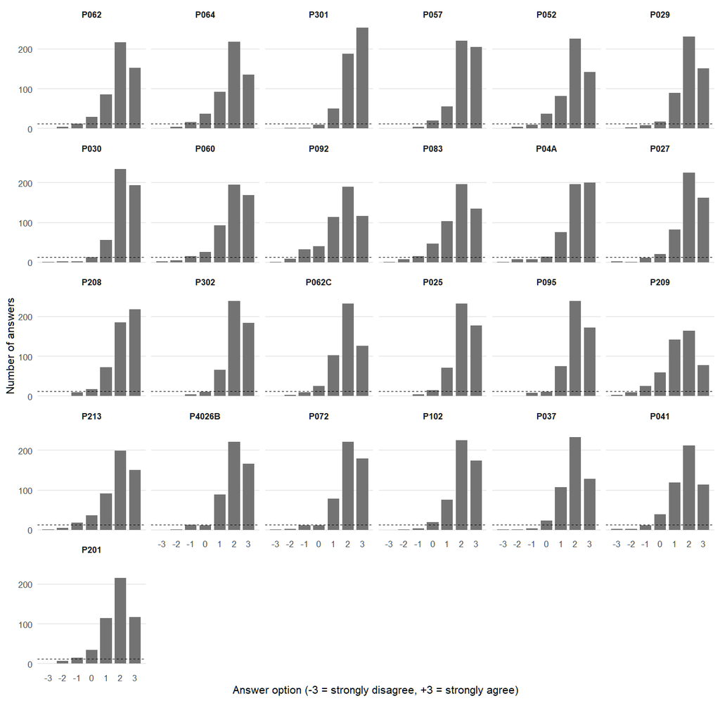

```r
draw_histograms(items_by_factor[["task-cognition"]])
```

### Size of the polychoric correlations

```r
correlation_summary <- do.call(rbind, lapply(names(results), function(g) {
  u <- results[[g]]$rho[upper.tri(results[[g]]$rho)]
  data.frame(group = g, pairs = length(u), min = min(u), median = median(u), max = max(u),
             share_above_0.30 = mean(u > .30), share_above_0.50 = mean(u > .50), negative = sum(u < 0))
}))
write.csv(correlation_summary, file.path(out_dir, "correlation-summary.csv"), row.names = FALSE)
knitr::kable(correlation_summary, digits = 3)
```

| group | pairs | min | median | max | share_above_0.30 | share_above_0.50 | negative |
| --- | --- | --- | --- | --- | --- | --- | --- |
| Tableau | 2080 | 0.081 | 0.473 | 0.805 | 0.924 | 0.406 | 0 |
| Qlik | 2080 | 0.030 | 0.398 | 0.751 | 0.788 | 0.184 | 0 |
| Power BI | 2080 | -0.123 | 0.314 | 0.708 | 0.539 | 0.071 | 23 |
| Gephi | 2080 | 0.091 | 0.507 | 0.778 | 0.954 | 0.523 | 0 |
| JMP | 2080 | 0.023 | 0.469 | 0.801 | 0.904 | 0.392 | 0 |
| Agg | 2080 | 0.162 | 0.434 | 0.723 | 0.944 | 0.225 | 0 |

### Number of factors: other criteria (whole sample)

Parallel analysis with `fa = "fa"` is the criterion of the original notebook. The criteria below are computed on the same polychoric matrix so that the suggested number of factors can be read against them; they do not change any loading. The parallel analyses on the matrix are repeated with 20 seeds to show how stable they are. Given a correlation matrix, `fa.parallel` compares its eigenvalues with those of random normal data (Pearson correlations); the version with `cor = "poly"` starts from the raw ratings and uses polychoric correlations for the random data as well.

```r
rho_agg <- results[["Agg"]]$rho
n_agg <- nrow(datasets[["Agg"]])
pa_runs <- t(sapply(1:20, function(s) {
  set.seed(s)
  p <- psych::fa.parallel(rho_agg, n.obs = n_agg, fa = "both", n.iter = params$pa_iterations, plot = FALSE)
  c(fa = p$nfact, pc = p$ncomp)
}))
```

```
## Parallel analysis suggests that the number of factors =  5  and the number of components =  3
## Parallel analysis suggests that the number of factors =  5  and the number of components =  3
## Parallel analysis suggests that the number of factors =  5  and the number of components =  3
## Parallel analysis suggests that the number of factors =  5  and the number of components =  3
## Parallel analysis suggests that the number of factors =  5  and the number of components =  3
## Parallel analysis suggests that the number of factors =  5  and the number of components =  3
## Parallel analysis suggests that the number of factors =  5  and the number of components =  3
## Parallel analysis suggests that the number of factors =  5  and the number of components =  3
## Parallel analysis suggests that the number of factors =  5  and the number of components =  3
## Parallel analysis suggests that the number of factors =  5  and the number of components =  3
## Parallel analysis suggests that the number of factors =  5  and the number of components =  3
## Parallel analysis suggests that the number of factors =  5  and the number of components =  3
## Parallel analysis suggests that the number of factors =  5  and the number of components =  3
## Parallel analysis suggests that the number of factors =  5  and the number of components =  3
## Parallel analysis suggests that the number of factors =  5  and the number of components =  3
## Parallel analysis suggests that the number of factors =  5  and the number of components =  3
## Parallel analysis suggests that the number of factors =  5  and the number of components =  3
## Parallel analysis suggests that the number of factors =  5  and the number of components =  3
## Parallel analysis suggests that the number of factors =  5  and the number of components =  3
## Parallel analysis suggests that the number of factors =  5  and the number of components =  3
```

```r
poly_pa <- if (params$poly_pa_iterations > 0) {
  set.seed(params$seed)
  psych::fa.parallel(datasets[["Agg"]], fa = "fa", cor = "poly", n.iter = params$poly_pa_iterations,
                     plot = FALSE)$nfact
} else NA
```

```
## Parallel analysis suggests that the number of factors =  5  and the number of components =  NA
```

```r
vss <- psych::VSS(rho_agg, n = 8, n.obs = n_agg, fm = "pa", plot = FALSE)
eigenvalues <- eigen(rho_agg, only.values = TRUE)$values
tab_runs <- function(x) paste(sprintf("%s (%d of 20 seeds)", names(table(x)), as.integer(table(x))), collapse = ", ")
criteria <- data.frame(
  criterion = c("Parallel analysis, factors (fa = \"fa\")", "Parallel analysis, principal components",
                sprintf("Parallel analysis, factors, polychoric simulated data (cor = \"poly\", %d iterations, seed %d)",
                        params$poly_pa_iterations, params$seed),
                "Velicer's MAP (minimum)", "Eigenvalues > 1 (Kaiser)"),
  suggested_factors = c(tab_runs(pa_runs[, "fa"]), tab_runs(pa_runs[, "pc"]), as.character(poly_pa),
                        as.character(which.min(vss$map)), as.character(sum(eigenvalues > 1))))
write.csv(criteria, file.path(out_dir, "number-of-factors-criteria-agg.csv"), row.names = FALSE)
knitr::kable(criteria)
```

| criterion | suggested_factors |
| --- | --- |
| Parallel analysis, factors (fa = “fa”) | 5 (20 of 20 seeds) |
| Parallel analysis, principal components | 3 (20 of 20 seeds) |
| Parallel analysis, factors, polychoric simulated data (cor = “poly”, 20 iterations, seed 257) | 5 |
| Velicer’s MAP (minimum) | 4 |
| Eigenvalues > 1 (Kaiser) | 9 |

```r
cat("First eigenvalues:", paste(round(eigenvalues[1:6], 2), collapse = ", "), "\n")
```

```
## First eigenvalues: 29.06, 3.12, 1.89, 1.34, 1.23, 1.11
```

### Stability of the parallel analysis (all groups)

The parallel analysis of the main run (one seed) is repeated with 20 seeds for each group, on the same polychoric matrices, to show how much the suggested number of factors depends on the random data.

```r
pa_stability <- do.call(rbind, lapply(names(results), function(g) {
  nf <- sapply(1:20, function(s) {
    set.seed(s)
    psych::fa.parallel(results[[g]]$rho, n.obs = nrow(datasets[[g]]), fa = "fa",
                       n.iter = params$pa_iterations, plot = FALSE)$nfact
  })
  data.frame(group = g, main_run = summary_table$parallel_n_factors[summary_table$group == g],
             over_20_seeds = tab_runs(nf))
}))
```

[output not shown]

[output cut: 65 more lines]

[output not shown]

```r
write.csv(pa_stability, file.path(out_dir, "parallel-analysis-stability.csv"), row.names = FALSE)
knitr::kable(pa_stability)
```

| group | main_run | over_20_seeds |
| --- | --- | --- |
| Tableau | 2 | 2 (20 of 20 seeds) |
| Qlik | 2 | 2 (20 of 20 seeds) |
| Power BI | 4 | 4 (20 of 20 seeds) |
| Gephi | 2 | 2 (20 of 20 seeds) |
| JMP | 3 | 2 (5 of 20 seeds), 3 (15 of 20 seeds) |
| Agg | 5 | 5 (20 of 20 seeds) |

### Scree plot figures for the paper

Same parallel analysis as the main run (`fa = "fa"`, 100 iterations, seed 257); only the drawing changes: the first 12 factors on a log scale, the mean eigenvalues of the random data, and a line at the number of factors suggested. Written to `output/plots/figure-scree-pooled.pdf` (main text) and `output/plots/figure-scree-by-system.pdf` (appendix).

```r
# --- figures of the scree plots with parallel analysis, for the paper -----------------------------
# Same analysis as the main run (fa = "fa", 100 iterations, seed 257); only the drawing changes:
# the first 12 factors, log scale, and a vertical line at the number of factors suggested.
scree_panel <- function(rho, n, title = "", k_max = 12, legend = FALSE) {
  set.seed(params$seed)
  pa <- psych::fa.parallel(rho, n.obs = n, fa = "fa", n.iter = params$pa_iterations, plot = FALSE)
  k <- seq_len(k_max)
  ylim <- range(c(pa$fa.values[k], pa$fa.sim[k]))
  plot(k, pa$fa.values[k], log = "y", type = "b", pch = 19, cex = 0.8, ylim = ylim, xaxt = "n",
       xlab = "Factor", ylab = "Eigenvalue (log scale)", main = title, cex.main = 1, font.main = 1, las = 1)
  axis(1, at = k)
  lines(k, pa$fa.sim[k], lty = 2, col = "grey40")
  abline(v = pa$nfact + 0.5, col = "grey60")
  mtext(sprintf("%d factor%s", pa$nfact, if (pa$nfact == 1) "" else "s"), side = 3, line = -1.2,
        at = pa$nfact + 0.6, adj = 0, cex = 0.8)
  if (legend) legend("topright", c("Observed data", "Random data (mean)"), lty = c(1, 2),
                     pch = c(19, NA), col = c("black", "grey40"), bty = "n", cex = 0.85)
  invisible(pa$nfact)
}

pdf(file.path(out_dir, "plots", "figure-scree-pooled.pdf"), width = 5.5, height = 3.6)
par(mar = c(4, 4.2, 1, 1))
scree_panel(results[["Agg"]]$rho, nrow(datasets[["Agg"]]), legend = TRUE)
```

```
## Parallel analysis suggests that the number of factors =  5  and the number of components =  NA
```

```r
dev.off()
```

```r
tools <- setdiff(names(datasets), "Agg")
draw_systems <- function() {
  par(mfrow = c(2, 3), mar = c(4, 4.2, 2, 1))
  for (g in tools) scree_panel(results[[g]]$rho, nrow(datasets[[g]]),
                               title = sprintf("%s (n = %d)", g, nrow(datasets[[g]])))
  plot.new()
  legend("center", c("Observed data", "Random data (mean)"), lty = c(1, 2), pch = c(19, NA),
         col = c("black", "grey40"), bty = "n")
}
pdf(file.path(out_dir, "plots", "figure-scree-by-system.pdf"), width = 9, height = 5.2)
draw_systems()
```

```
## Parallel analysis suggests that the number of factors =  2  and the number of components =  NA
```

```
## Parallel analysis suggests that the number of factors =  2  and the number of components =  NA
```

```
## Parallel analysis suggests that the number of factors =  4  and the number of components =  NA
```

```
## Parallel analysis suggests that the number of factors =  2  and the number of components =  NA
```

```
## Parallel analysis suggests that the number of factors =  3  and the number of components =  NA
```

```r
dev.off()
```

```
## Parallel analysis suggests that the number of factors =  2  and the number of components =  NA
```

```
## Parallel analysis suggests that the number of factors =  2  and the number of components =  NA
```

```
## Parallel analysis suggests that the number of factors =  4  and the number of components =  NA
```

```
## Parallel analysis suggests that the number of factors =  2  and the number of components =  NA
```

```
## Parallel analysis suggests that the number of factors =  3  and the number of components =  NA
```

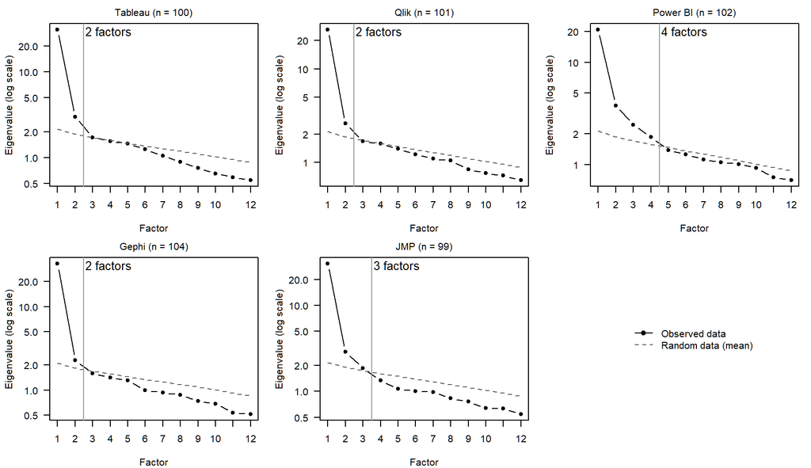

```r
draw_systems()
```

### Collapsed vs uncollapsed data (whole sample)

The EFA of the whole sample is repeated on the **uncollapsed** ratings (same polychoric correlations, principal axis, promax) to check that collapsing the rare options does not change the structure. For each number of factors, the factors of the two solutions are matched by Tucker’s congruence coefficient, and the items are compared by their primary factor (largest loading).

```r
dir.create(file.path(out_dir, "loadings-uncollapsed"), showWarnings = FALSE)
rho_raw <- psych::polychoric(raw)$rho
write.csv(rho_raw, file.path(out_dir, "correlations", "polychoric-agg-uncollapsed.csv"))
items <- names(agg)
uncollapsed_rows <- list()
variance_rows <- list()
for (k in seq_len(params$n_factors_max)) {
  rot <- if (k == 1) "none" else "promax"
  efa_u <- psych::fa.sort(psych::fa(rho_raw, n.obs = nrow(raw), nfactors = k, rotate = rot, fm = "pa"))
  efa_c <- psych::fa.sort(psych::fa(rho_agg, n.obs = n_agg, nfactors = k, rotate = rot, fm = "pa"))
  L_u <- unclass(efa_u$loadings)[items, , drop = FALSE]
  L_c <- unclass(efa_c$loadings)[items, , drop = FALSE]
  write.csv(data.frame(terms = rownames(unclass(efa_u$loadings)), unclass(efa_u$loadings), check.names = FALSE),
            file.path(out_dir, "loadings-uncollapsed", sprintf("pa-%d-factors-agg.csv", k)), row.names = FALSE)
  cong <- psych::factor.congruence(L_c, L_u)
  match <- apply(abs(cong), 1, which.max)              # uncollapsed factor matched to each collapsed factor
  prim_c <- apply(L_c, 1, which.max)
  prim_u <- apply(L_u, 1, which.max)
  changed <- items[match[prim_c] != prim_u]
  uncollapsed_rows[[k]] <- data.frame(
    factors = k,
    congruence = paste(sprintf("%.3f", sapply(seq_len(k), function(i) cong[i, match[i]])), collapse = ", "),
    one_to_one_match = length(unique(match)) == k,
    items_same_primary_factor = sum(match[prim_c] == prim_u),
    items_changing_factor = paste(changed, collapse = " "),
    cum_variance_collapsed = sum(efa_c$Vaccounted["Proportion Var", ]),
    cum_variance_uncollapsed = sum(efa_u$Vaccounted["Proportion Var", ]))
  # variance explained by each factor, uncollapsed factor matched to the collapsed one
  pv_c <- efa_c$Vaccounted["Proportion Var", colnames(L_c)]
  pv_u <- efa_u$Vaccounted["Proportion Var", colnames(L_u)]
  variance_rows[[k]] <- rbind(
    data.frame(solution = paste(k, if (k == 1) "factor" else "factors"), factor = colnames(L_c),
               collapsed = unname(pv_c), uncollapsed = unname(pv_u[match])),
    data.frame(solution = paste(k, if (k == 1) "factor" else "factors"), factor = "Total",
               collapsed = sum(pv_c), uncollapsed = sum(pv_u)))
}
variance_explained <- do.call(rbind, variance_rows)
variance_explained$difference <- variance_explained$collapsed - variance_explained$uncollapsed
write.csv(variance_explained, file.path(out_dir, "variance-explained-agg.csv"), row.names = FALSE)

uncollapsed_comparison <- do.call(rbind, uncollapsed_rows)
write.csv(uncollapsed_comparison, file.path(out_dir, "collapsed-vs-uncollapsed-agg.csv"), row.names = FALSE)
knitr::kable(uncollapsed_comparison, digits = 3)
```

| factors | congruence | one_to_one_match | items_same_primary_factor | items_changing_factor | cum_variance_collapsed | cum_variance_uncollapsed |
| --- | --- | --- | --- | --- | --- | --- |
| 1 | 1.000 | TRUE | 65 |  | 0.439 | 0.434 |
| 2 | 1.000, 1.000 | TRUE | 64 | P201 | 0.480 | 0.475 |
| 3 | 1.000, 1.000, 1.000 | TRUE | 62 | P031 P06 P102 | 0.502 | 0.496 |
| 4 | 1.000, 1.000, 1.000, 0.990 | TRUE | 63 | P06 P201 | 0.516 | 0.510 |
| 5 | 1.000, 1.000, 1.000, 1.000, 1.000 | TRUE | 63 | P06 P103 | 0.528 | 0.523 |
| 6 | 1.000, 1.000, 0.990, 1.000, 0.990, 0.930 | TRUE | 60 | P012 P025 P037 P041 P092 | 0.539 | 0.534 |

Proportion of variance explained by each factor and in total, for the 1–6 factor solutions. The factors are named as in the collapsed solution; each uncollapsed factor is the one matched to it by congruence.

```r
knitr::kable(variance_explained, digits = 3)
```

| solution | factor | collapsed | uncollapsed | difference |
| --- | --- | --- | --- | --- |
| 1 factor | PA1 | 0.439 | 0.434 | 0.005 |
| 1 factor | Total | 0.439 | 0.434 | 0.005 |
| 2 factors | PA1 | 0.288 | 0.285 | 0.003 |
| 2 factors | PA2 | 0.192 | 0.190 | 0.002 |
| 2 factors | Total | 0.480 | 0.475 | 0.005 |
| 3 factors | PA1 | 0.189 | 0.180 | 0.008 |
| 3 factors | PA2 | 0.161 | 0.159 | 0.002 |
| 3 factors | PA3 | 0.152 | 0.157 | -0.005 |
| 3 factors | Total | 0.502 | 0.496 | 0.006 |
| 4 factors | PA1 | 0.178 | 0.180 | -0.001 |
| 4 factors | PA2 | 0.148 | 0.146 | 0.002 |
| 4 factors | PA3 | 0.125 | 0.126 | 0.000 |
| 4 factors | PA4 | 0.064 | 0.060 | 0.004 |
| 4 factors | Total | 0.516 | 0.510 | 0.005 |
| 5 factors | PA2 | 0.151 | 0.150 | 0.001 |
| 5 factors | PA3 | 0.144 | 0.145 | -0.001 |
| 5 factors | PA1 | 0.107 | 0.096 | 0.011 |
| 5 factors | PA5 | 0.097 | 0.105 | -0.008 |
| 5 factors | PA4 | 0.029 | 0.026 | 0.002 |
| 5 factors | Total | 0.528 | 0.523 | 0.005 |
| 6 factors | PA2 | 0.145 | 0.147 | -0.002 |
| 6 factors | PA3 | 0.138 | 0.138 | -0.001 |
| 6 factors | PA1 | 0.110 | 0.097 | 0.013 |
| 6 factors | PA5 | 0.093 | 0.105 | -0.012 |
| 6 factors | PA4 | 0.030 | 0.027 | 0.004 |
| 6 factors | PA6 | 0.023 | 0.019 | 0.004 |
| 6 factors | Total | 0.539 | 0.534 | 0.005 |

### Fit indices

```r
knitr::kable(fit_table, digits = 3)
```

| group | factors | chi_sq | df | rmsea | rmsea_lower | rmsea_upper | cfi | tli | bic | rmsr |
| --- | --- | --- | --- | --- | --- | --- | --- | --- | --- | --- |
| Tableau | 1 | 26804.920 | 2015 | 0.351 | 0.349 | 0.356 | 0.113 | 0.076 | 17525.502 | 0.060 |
| Tableau | 2 | 26242.271 | 1951 | 0.353 | 0.351 | 0.358 | 0.131 | 0.056 | 17257.584 | 0.050 |
| Tableau | 3 | 25816.590 | 1888 | 0.356 | 0.354 | 0.362 | 0.144 | 0.030 | 17122.028 | 0.045 |
| Tableau | 4 | 25400.370 | 1826 | 0.359 | 0.357 | 0.365 | 0.157 | 0.002 | 16991.329 | 0.042 |
| Tableau | 5 | 25006.393 | 1765 | 0.363 | 0.361 | 0.369 | 0.169 | -0.028 | 16878.267 | 0.038 |
| Tableau | 6 | 24632.845 | 1705 | 0.367 | 0.364 | 0.373 | 0.180 | -0.060 | 16781.030 | 0.035 |
| Qlik | 1 | 23691.245 | 2015 | 0.326 | 0.324 | 0.332 | 0.105 | 0.067 | 14391.777 | 0.060 |
| Qlik | 2 | 23247.546 | 1951 | 0.329 | 0.327 | 0.334 | 0.120 | 0.044 | 14243.446 | 0.052 |
| Qlik | 3 | 22886.723 | 1888 | 0.332 | 0.330 | 0.337 | 0.133 | 0.017 | 14173.376 | 0.049 |
| Qlik | 4 | 22544.228 | 1826 | 0.335 | 0.333 | 0.341 | 0.144 | -0.013 | 14117.018 | 0.045 |
| Qlik | 5 | 22209.377 | 1765 | 0.339 | 0.336 | 0.344 | 0.155 | -0.044 | 14063.689 | 0.042 |
| Qlik | 6 | 21881.155 | 1705 | 0.342 | 0.340 | 0.348 | 0.167 | -0.077 | 14012.375 | 0.039 |
| Power BI | 1 | 21091.085 | 2015 | 0.304 | 0.302 | 0.310 | 0.090 | 0.052 | 11771.765 | 0.073 |
| Power BI | 2 | 20565.179 | 1951 | 0.306 | 0.304 | 0.311 | 0.112 | 0.035 | 11541.857 | 0.059 |
| Power BI | 3 | 20179.638 | 1888 | 0.308 | 0.306 | 0.314 | 0.127 | 0.011 | 11447.689 | 0.052 |
| Power BI | 4 | 19840.908 | 1826 | 0.311 | 0.309 | 0.316 | 0.141 | -0.017 | 11395.708 | 0.048 |
| Power BI | 5 | 19545.405 | 1765 | 0.314 | 0.312 | 0.320 | 0.152 | -0.049 | 11382.328 | 0.045 |
| Power BI | 6 | 19255.089 | 1705 | 0.318 | 0.315 | 0.323 | 0.163 | -0.082 | 11369.511 | 0.042 |
| Gephi | 1 | 26232.715 | 2015 | 0.340 | 0.338 | 0.345 | 0.129 | 0.093 | 16874.267 | 0.052 |
| Gephi | 2 | 25758.325 | 1951 | 0.342 | 0.340 | 0.348 | 0.144 | 0.071 | 16697.118 | 0.046 |
| Gephi | 3 | 25373.900 | 1888 | 0.346 | 0.344 | 0.351 | 0.155 | 0.044 | 16605.290 | 0.042 |
| Gephi | 4 | 24998.837 | 1826 | 0.349 | 0.347 | 0.355 | 0.167 | 0.016 | 16518.179 | 0.038 |
| Gephi | 5 | 24614.631 | 1765 | 0.353 | 0.351 | 0.358 | 0.178 | -0.013 | 16417.281 | 0.035 |
| Gephi | 6 | 24262.238 | 1705 | 0.357 | 0.354 | 0.362 | 0.189 | -0.045 | 16343.551 | 0.033 |
| JMP | 1 | 26261.382 | 2015 | 0.348 | 0.347 | 0.354 | 0.114 | 0.077 | 17002.215 | 0.057 |
| JMP | 2 | 25721.597 | 1951 | 0.351 | 0.349 | 0.356 | 0.132 | 0.056 | 16756.518 | 0.047 |
| JMP | 3 | 25301.500 | 1888 | 0.354 | 0.352 | 0.360 | 0.145 | 0.030 | 16625.913 | 0.042 |
| JMP | 4 | 24938.531 | 1826 | 0.357 | 0.355 | 0.363 | 0.156 | 0.000 | 16547.842 | 0.039 |
| JMP | 5 | 24591.000 | 1765 | 0.361 | 0.359 | 0.367 | 0.166 | -0.032 | 16480.614 | 0.037 |
| JMP | 6 | 24262.539 | 1705 | 0.365 | 0.363 | 0.372 | 0.176 | -0.066 | 16427.860 | 0.035 |
| Agg | 1 | 7455.256 | 2015 | 0.073 | 0.071 | 0.075 | 0.752 | 0.744 | -5091.216 | 0.040 |
| Agg | 2 | 5847.389 | 1951 | 0.063 | 0.061 | 0.065 | 0.823 | 0.810 | -6300.584 | 0.029 |
| Agg | 3 | 5221.645 | 1888 | 0.059 | 0.057 | 0.061 | 0.848 | 0.832 | -6534.056 | 0.025 |
| Agg | 4 | 4854.440 | 1826 | 0.057 | 0.055 | 0.059 | 0.862 | 0.842 | -6515.216 | 0.023 |
| Agg | 5 | 4545.238 | 1765 | 0.056 | 0.054 | 0.058 | 0.873 | 0.850 | -6444.599 | 0.021 |
| Agg | 6 | 4282.998 | 1705 | 0.055 | 0.053 | 0.057 | 0.883 | 0.855 | -6333.247 | 0.020 |

`psych::fa` computes χ², CFI, TLI, RMSEA and BIC with a maximum-likelihood formula applied to the polychoric matrix, also for principal axis extraction. RMSR is the root mean square of the residual correlations (not the SRMR of a CFA). The whole-sample fit is also written as a LaTeX table for the paper (`output/table-efa-fit.tex`, needs `booktabs` and `graphicx`); the CFA of the same structures is in step 03.

```r
f <- fit_table[fit_table$group == "Agg", ]
num <- function(x, d) sub("^-", "$-$", formatC(x, format = "f", digits = d, big.mark = ","))
rows <- sprintf("%d & %s & %d & %s & %s & %s [%s, %s] & %s & %s \\\\",
                f$factors, num(f$chi_sq, 2), as.integer(f$df), num(f$cfi, 3), num(f$tli, 3),
                num(f$rmsea, 3), num(f$rmsea_lower, 3), num(f$rmsea_upper, 3), num(f$rmsr, 3), num(f$bic, 2))
writeLines(c(
  "\\begin{table*}[htbp]",  # full width (two-column layout)
  "\\centering",
  "\\caption{Fit of the exploratory factor analysis solutions with 1 to 6 factors (whole sample, $N = 506$; principal axis factoring on polychoric correlations).}",
  "\\label{tab:efa-fit}",
  "\\resizebox{\\textwidth}{!}{%",
  "\\begin{tabular}{rrrrrcrr}",
  "\\toprule",
  "Factors & $\\chi^2$ & df & CFI & TLI & RMSEA [90\\% CI] & RMSR & BIC \\\\",
  "\\midrule",
  rows,
  "\\bottomrule",
  "\\end{tabular}}",
  "\\end{table*}"), file.path(out_dir, "table-efa-fit.tex"))
cat(readLines(file.path(out_dir, "table-efa-fit.tex")), sep = "\n")
```

```
## \begin{table*}[htbp]
## \centering
## \caption{Fit of the exploratory factor analysis solutions with 1 to 6 factors (whole sample, $N = 506$; principal axis factoring on polychoric correlations).}
## \label{tab:efa-fit}
## \resizebox{\textwidth}{!}{%
## \begin{tabular}{rrrrrcrr}
## \toprule
## Factors & $\chi^2$ & df & CFI & TLI & RMSEA [90\% CI] & RMSR & BIC \\
## \midrule
## 1 & 7,455.26 & 2015 & 0.752 & 0.744 & 0.073 [0.071, 0.075] & 0.040 & $-$5,091.22 \\
## 2 & 5,847.39 & 1951 & 0.823 & 0.810 & 0.063 [0.061, 0.065] & 0.029 & $-$6,300.58 \\
## 3 & 5,221.65 & 1888 & 0.848 & 0.832 & 0.059 [0.057, 0.061] & 0.025 & $-$6,534.06 \\
## 4 & 4,854.44 & 1826 & 0.862 & 0.842 & 0.057 [0.055, 0.059] & 0.023 & $-$6,515.22 \\
## 5 & 4,545.24 & 1765 & 0.873 & 0.850 & 0.056 [0.054, 0.058] & 0.021 & $-$6,444.60 \\
## 6 & 4,283.00 & 1705 & 0.883 & 0.855 & 0.055 [0.053, 0.057] & 0.020 & $-$6,333.25 \\
## \bottomrule
## \end{tabular}}
## \end{table*}
```

### Polychoric correlations (whole sample)

```r
rho_agg <- results[["Agg"]]$rho
pdf(file.path(out_dir, "plots", "polychoric-agg.pdf"), width = 15, height = 15)
corrplot(rho_agg, method = "color", cl.cex = 1.5, tl.pos = "lt", tl.col = "black", tl.cex = 1.0,
         tl.srt = 90, cl.pos = "r", type = "lower")
dev.off()
```

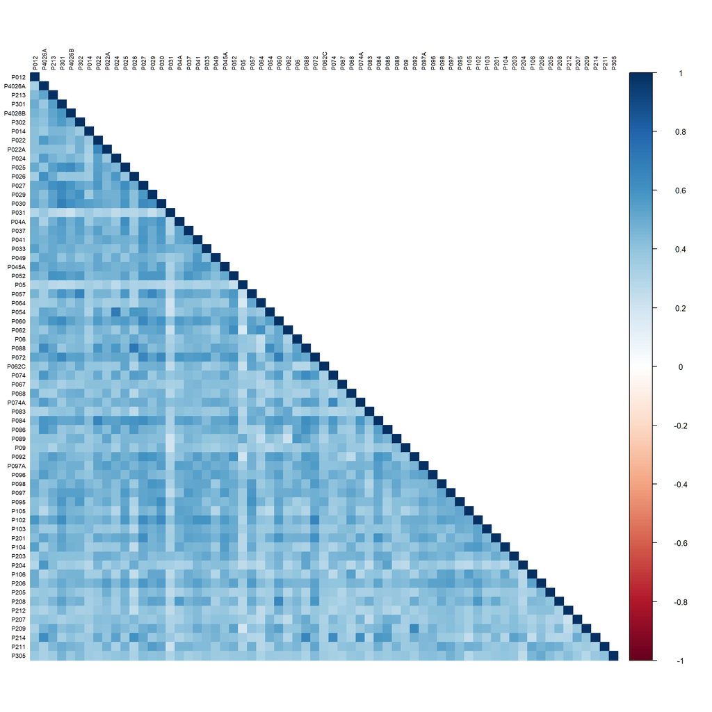

```r
corrplot(rho_agg, method = "color", tl.pos = "lt", tl.col = "black", tl.cex = 0.6, tl.srt = 90,
         cl.pos = "r", type = "lower")
```

### Three-factor solution (whole sample)

```r
three <- read.csv(file.path(out_dir, "loadings", "pa-3-factors-agg.csv"), check.names = FALSE)
knitr::kable(three, digits = 3)
```

| terms | PA1 | PA2 | PA3 |
| --- | --- | --- | --- |
| P062 | 0.828 | 0.001 | -0.144 |
| P064 | 0.747 | -0.016 | -0.122 |
| P301 | 0.734 | -0.098 | 0.157 |
| P057 | 0.709 | -0.175 | 0.234 |
| P052 | 0.709 | 0.173 | -0.080 |
| P029 | 0.606 | 0.041 | 0.155 |
| P030 | 0.597 | 0.008 | 0.238 |
| P060 | 0.580 | 0.308 | -0.040 |
| P092 | 0.563 | 0.491 | -0.276 |
| P083 | 0.562 | 0.015 | 0.042 |
| P04A | 0.561 | -0.027 | 0.211 |
| P027 | 0.543 | 0.277 | 0.045 |
| P208 | 0.540 | -0.038 | 0.201 |
| P302 | 0.514 | -0.002 | 0.255 |
| P062C | 0.508 | -0.021 | 0.165 |
| P025 | 0.489 | -0.005 | 0.319 |
| P095 | 0.476 | -0.082 | 0.351 |
| P209 | 0.472 | 0.380 | -0.152 |
| P213 | 0.468 | 0.380 | -0.056 |
| P4026B | 0.437 | 0.111 | 0.217 |
| P072 | 0.429 | 0.212 | 0.219 |
| P102 | 0.408 | 0.028 | 0.379 |
| P037 | 0.396 | 0.087 | 0.310 |
| P041 | 0.362 | 0.212 | 0.239 |
| P201 | 0.354 | 0.340 | 0.091 |
| P088 | -0.107 | 0.892 | 0.017 |
| P026 | -0.081 | 0.884 | -0.068 |
| P214 | -0.177 | 0.870 | 0.033 |
| P4026A | 0.001 | 0.793 | -0.027 |
| P074 | -0.032 | 0.727 | 0.051 |
| P086 | 0.038 | 0.726 | -0.004 |
| P054 | 0.257 | 0.656 | -0.172 |
| P024 | 0.204 | 0.654 | -0.106 |
| P204 | 0.029 | 0.618 | -0.023 |
| P074A | -0.003 | 0.590 | 0.177 |
| P049 | 0.138 | 0.517 | 0.080 |
| P084 | 0.310 | 0.514 | 0.036 |
| P022 | 0.239 | 0.506 | 0.048 |
| P207 | -0.165 | 0.466 | 0.354 |
| P06 | -0.084 | 0.427 | 0.399 |
| P096 | 0.105 | 0.415 | 0.271 |
| P203 | 0.035 | 0.413 | 0.296 |
| P031 | 0.011 | 0.272 | 0.242 |
| P106 | 0.170 | -0.267 | 0.775 |
| P05 | -0.358 | 0.201 | 0.699 |
| P089 | -0.225 | 0.280 | 0.649 |
| P068 | 0.172 | -0.127 | 0.626 |
| P098 | 0.189 | 0.003 | 0.582 |
| P105 | 0.330 | -0.221 | 0.578 |
| P211 | 0.248 | -0.073 | 0.520 |
| P097 | 0.215 | 0.057 | 0.516 |
| P104 | 0.334 | -0.134 | 0.497 |
| P305 | 0.076 | 0.077 | 0.482 |
| P205 | 0.154 | 0.030 | 0.457 |
| P012 | 0.263 | 0.001 | 0.454 |
| P022A | 0.103 | 0.199 | 0.450 |
| P206 | 0.271 | 0.061 | 0.448 |
| P067 | -0.033 | 0.264 | 0.432 |
| P09 | 0.120 | 0.100 | 0.424 |
| P212 | 0.195 | 0.019 | 0.387 |
| P103 | 0.341 | 0.001 | 0.358 |
| P097A | 0.165 | 0.269 | 0.353 |
| P014 | 0.158 | 0.165 | 0.336 |
| P033 | 0.241 | 0.211 | 0.320 |
| P045A | 0.252 | 0.247 | 0.308 |
| — VARIANCE EXPLAINED — | NA | NA | NA |
| SS loadings | 12.276 | 10.464 | 9.883 |
| Proportion Var | 0.189 | 0.161 | 0.152 |
| Cumulative Var | 0.189 | 0.350 | 0.502 |
| Proportion Explained | 0.376 | 0.321 | 0.303 |
| Cumulative Proportion | 0.376 | 0.697 | 1.000 |

## Comparison with the run of 2026-03-18

```r
ref_dir <- here(params$reference_dir)
code_of <- function(x) sub("[.-].*$", "", x)

read_reference_loadings <- function(g, k) {
  f <- file.path(ref_dir, g, sprintf("PA1 Stimuli %d factors - %s.csv", k, g))
  r <- read.csv(f, check.names = FALSE)
  r <- r[seq_len(which(r$terms == "--- VARIANCE EXPLAINED ---") - 1), ]
  r$terms <- code_of(r$terms)
  r
}
read_new_loadings <- function(g, k) {
  f <- file.path(out_dir, "loadings", sprintf("pa-%d-factors-%s.csv", k, group_slug(g)))
  r <- read.csv(f, check.names = FALSE)
  r[seq_len(which(r$terms == "--- VARIANCE EXPLAINED ---") - 1), ]
}

loading_checks <- do.call(rbind, lapply(names(datasets), function(g) {
  do.call(rbind, lapply(seq_len(params$n_factors_max), function(k) {
    old <- read_reference_loadings(g, k)
    new <- read_new_loadings(g, k)
    cols <- setdiff(names(old), "terms")
    new <- new[match(old$terms, new$terms), c("terms", cols)]
    diff <- max(abs(as.matrix(old[, cols]) - as.matrix(new[, cols])))
    data.frame(group = g, factors = k, items = nrow(old),
               same_item_order = identical(old$terms, read_new_loadings(g, k)$terms),
               max_abs_diff_loading = diff)
  }))
}))

corr_checks <- do.call(rbind, lapply(names(datasets), function(g) {
  old <- as.matrix(read.csv(file.path(ref_dir, "correlations", paste0("corr", g, "-POLY.csv")),
                            row.names = 1, check.names = FALSE))
  new <- results[[g]]$rho[rownames(old), colnames(old)]
  data.frame(group = g, max_abs_diff_polychoric = max(abs(old - new)))
}))

ref_summary <- read.csv(file.path(ref_dir, "Summary of Measures of Sampling Adequacy.csv"), check.names = FALSE)
kmo_checks <- data.frame(group = ref_summary$System,
                         kmo_2026_03_18 = ref_summary$`KMO Poly`,
                         kmo_now = summary_table$kmo[match(ref_summary$System, summary_table$group)],
                         n_factors_2026_03_18 = ref_summary$`Number of factors`,
                         n_factors_now = summary_table$parallel_n_factors[match(ref_summary$System, summary_table$group)])
kmo_checks$abs_diff_kmo <- abs(kmo_checks$kmo_2026_03_18 - kmo_checks$kmo_now)

checks <- merge(loading_checks, corr_checks, by = "group")
write.csv(checks, file.path(out_dir, "check-vs-2026-03-18.csv"), row.names = FALSE)
write.csv(kmo_checks, file.path(out_dir, "check-kmo-vs-2026-03-18.csv"), row.names = FALSE)

tol <- 1e-6
cat(sprintf("Loadings: largest difference %.2e over %d solutions; correlations: largest difference %.2e; KMO: largest difference %.2e.\n",
            max(checks$max_abs_diff_loading), nrow(loading_checks),
            max(corr_checks$max_abs_diff_polychoric), max(kmo_checks$abs_diff_kmo)))
```

```
## Loadings: largest difference 0.00e+00 over 36 solutions; correlations: largest difference 5.55e-16; KMO: largest difference 4.44e-16.
```

```r
cat(if (max(checks$max_abs_diff_loading) < tol && max(corr_checks$max_abs_diff_polychoric) < tol &&
        max(kmo_checks$abs_diff_kmo) < tol)
  "REPRODUCED: every loading, correlation and KMO matches the run of 2026-03-18 (|difference| < 1e-6).\n" else
  "DIFFERENT: see the tables below.\n")
```

```
## REPRODUCED: every loading, correlation and KMO matches the run of 2026-03-18 (|difference| < 1e-6).
```

```r
knitr::kable(loading_checks, digits = 8)
```

| group | factors | items | same_item_order | max_abs_diff_loading |
| --- | --- | --- | --- | --- |
| Tableau | 1 | 65 | TRUE | 0 |
| Tableau | 2 | 65 | TRUE | 0 |
| Tableau | 3 | 65 | TRUE | 0 |
| Tableau | 4 | 65 | TRUE | 0 |
| Tableau | 5 | 65 | TRUE | 0 |
| Tableau | 6 | 65 | TRUE | 0 |
| Qlik | 1 | 65 | TRUE | 0 |
| Qlik | 2 | 65 | TRUE | 0 |
| Qlik | 3 | 65 | TRUE | 0 |
| Qlik | 4 | 65 | TRUE | 0 |
| Qlik | 5 | 65 | TRUE | 0 |
| Qlik | 6 | 65 | TRUE | 0 |
| Power BI | 1 | 65 | TRUE | 0 |
| Power BI | 2 | 65 | TRUE | 0 |
| Power BI | 3 | 65 | TRUE | 0 |
| Power BI | 4 | 65 | TRUE | 0 |
| Power BI | 5 | 65 | TRUE | 0 |
| Power BI | 6 | 65 | TRUE | 0 |
| Gephi | 1 | 65 | TRUE | 0 |
| Gephi | 2 | 65 | TRUE | 0 |
| Gephi | 3 | 65 | TRUE | 0 |
| Gephi | 4 | 65 | TRUE | 0 |
| Gephi | 5 | 65 | TRUE | 0 |
| Gephi | 6 | 65 | TRUE | 0 |
| JMP | 1 | 65 | TRUE | 0 |
| JMP | 2 | 65 | TRUE | 0 |
| JMP | 3 | 65 | TRUE | 0 |
| JMP | 4 | 65 | TRUE | 0 |
| JMP | 5 | 65 | TRUE | 0 |
| JMP | 6 | 65 | TRUE | 0 |
| Agg | 1 | 65 | TRUE | 0 |
| Agg | 2 | 65 | TRUE | 0 |
| Agg | 3 | 65 | TRUE | 0 |
| Agg | 4 | 65 | TRUE | 0 |
| Agg | 5 | 65 | TRUE | 0 |
| Agg | 6 | 65 | TRUE | 0 |

```r
knitr::kable(corr_checks, digits = 8)
```

| group | max_abs_diff_polychoric |
| --- | --- |
| Tableau | 0 |
| Qlik | 0 |
| Power BI | 0 |
| Gephi | 0 |
| JMP | 0 |
| Agg | 0 |

```r
knitr::kable(kmo_checks, digits = 6)
```

| group | kmo_2026_03_18 | kmo_now | n_factors_2026_03_18 | n_factors_now | abs_diff_kmo |
| --- | --- | --- | --- | --- | --- |
| Tableau | 0.811530 | 0.811530 | 2 | 2 | 0 |
| Qlik | 0.724631 | 0.724631 | 2 | 2 | 0 |
| Power BI | 0.592197 | 0.592197 | 4 | 4 | 0 |
| Gephi | 0.815729 | 0.815729 | 2 | 2 | 0 |
| JMP | 0.811490 | 0.811490 | 2 | 3 | 0 |
| Agg | 0.963523 | 0.963523 | 5 | 5 | 0 |

The number of factors suggested by parallel analysis depends on the random simulation; the run of 2026-03-18 set no seed, so a difference there is expected and does not mean that the data or the method differ.

## Session

```r
writeLines(c(paste("rendered:", format(Sys.time())),
             paste("data_dir:", params$data_dir),
             paste0("md5 ", names(groups), ": ", tools::md5sum(file.path(data_dir, groups)))),
           file.path(out_dir, "run_info.txt"))
```